# Airline

Shakib

2024-07-06

## Highlights of the Dataset

This is an Airline Dataset having 227,496 flight information of an USAirport in the year 2011. There is total 21 columns in the dataset. Below is the brief of the columns.

```r
#load library
library(tidyverse)
#load csv from github(uploaded for Assignment_02_Group_04)
airline <- read.csv("https://raw.githubusercontent.com/maeshakib/Airline-Data-Analysis-R/main/dataset.csv", stringsAsFactors = FALSE)
#show data structure of dataset
str(airline)
```

```
## 'data.frame':    227496 obs. of  21 variables:
##  $ Year             : int  2011 2011 2011 2011 2011 2011 2011 2011 2011 2011 ...
##  $ Month            : int  1 1 1 1 1 1 1 1 1 1 ...
##  $ DayofMonth       : int  1 2 3 4 5 6 7 8 9 10 ...
##  $ DayOfWeek        : int  6 7 1 2 3 4 5 6 7 1 ...
##  $ DepTime          : int  1400 1401 1352 1403 1405 1359 1359 1355 1443 1443 ...
##  $ ArrTime          : int  1500 1501 1502 1513 1507 1503 1509 1454 1554 1553 ...
##  $ UniqueCarrier    : chr  "AA" "AA" "AA" "AA" ...
##  $ FlightNum        : int  428 428 428 428 428 428 428 428 428 428 ...
##  $ TailNum          : chr  "N576AA" "N557AA" "N541AA" "N403AA" ...
##  $ ActualElapsedTime: int  60 60 70 70 62 64 70 59 71 70 ...
##  $ AirTime          : int  40 45 48 39 44 45 43 40 41 45 ...
##  $ ArrDelay         : int  -10 -9 -8 3 -3 -7 -1 -16 44 43 ...
##  $ DepDelay         : int  0 1 -8 3 5 -1 -1 -5 43 43 ...
##  $ Origin           : chr  "IAH" "IAH" "IAH" "IAH" ...
##  $ Dest             : chr  "DFW" "DFW" "DFW" "DFW" ...
##  $ Distance         : int  224 224 224 224 224 224 224 224 224 224 ...
##  $ TaxiIn           : int  7 6 5 9 9 6 12 7 8 6 ...
##  $ TaxiOut          : int  13 9 17 22 9 13 15 12 22 19 ...
##  $ Cancelled        : int  0 0 0 0 0 0 0 0 0 0 ...
##  $ CancellationCode : chr  "" "" "" "" ...
##  $ Diverted         : int  0 0 0 0 0 0 0 0 0 0 ...
```

## Loading Library and Dataset Preparation

```r
#install tidyverse if not available
#install.packages("tidyverse")


#summary of data set
summary(airline)
```

```
##       Year          Month          DayofMonth      DayOfWeek        DepTime
##  Min.   :2011   Min.   : 1.000   Min.   : 1.00   Min.   :1.000   Min.   :   1
##  1st Qu.:2011   1st Qu.: 4.000   1st Qu.: 8.00   1st Qu.:2.000   1st Qu.:1021
##  Median :2011   Median : 7.000   Median :16.00   Median :4.000   Median :1416
##  Mean   :2011   Mean   : 6.514   Mean   :15.74   Mean   :3.948   Mean   :1396
##  3rd Qu.:2011   3rd Qu.: 9.000   3rd Qu.:23.00   3rd Qu.:6.000   3rd Qu.:1801
##  Max.   :2011   Max.   :12.000   Max.   :31.00   Max.   :7.000   Max.   :2400
##                                                                  NA's   :2905
##     ArrTime     UniqueCarrier        FlightNum      TailNum
##  Min.   :   1   Length:227496      Min.   :   1   Length:227496
##  1st Qu.:1215   Class :character   1st Qu.: 855   Class :character
##  Median :1617   Mode  :character   Median :1696   Mode  :character
##  Mean   :1578                      Mean   :1962
##  3rd Qu.:1953                      3rd Qu.:2755
##  Max.   :2400                      Max.   :7290
##  NA's   :3066
##  ActualElapsedTime    AirTime         ArrDelay          DepDelay
##  Min.   : 34.0     Min.   : 11.0   Min.   :-70.000   Min.   :-33.000
##  1st Qu.: 77.0     1st Qu.: 58.0   1st Qu.: -8.000   1st Qu.: -3.000
##  Median :128.0     Median :107.0   Median :  0.000   Median :  0.000
##  Mean   :129.3     Mean   :108.1   Mean   :  7.094   Mean   :  9.445
##  3rd Qu.:165.0     3rd Qu.:141.0   3rd Qu.: 11.000   3rd Qu.:  9.000
##  Max.   :575.0     Max.   :549.0   Max.   :978.000   Max.   :981.000
##  NA's   :3622      NA's   :3622    NA's   :3622      NA's   :2905
##     Origin              Dest              Distance          TaxiIn
##  Length:227496      Length:227496      Min.   :  79.0   Min.   :  1.000
##  Class :character   Class :character   1st Qu.: 376.0   1st Qu.:  4.000
##  Mode  :character   Mode  :character   Median : 809.0   Median :  5.000
##                                        Mean   : 787.8   Mean   :  6.099
##                                        3rd Qu.:1042.0   3rd Qu.:  7.000
##                                        Max.   :3904.0   Max.   :165.000
##                                                         NA's   :3066
##     TaxiOut         Cancelled       CancellationCode      Diverted
##  Min.   :  1.00   Min.   :0.00000   Length:227496      Min.   :0.000000
##  1st Qu.: 10.00   1st Qu.:0.00000   Class :character   1st Qu.:0.000000
##  Median : 14.00   Median :0.00000   Mode  :character   Median :0.000000
##  Mean   : 15.09   Mean   :0.01307                      Mean   :0.002853
##  3rd Qu.: 18.00   3rd Qu.:0.00000                      3rd Qu.:0.000000
##  Max.   :163.00   Max.   :1.00000                      Max.   :1.000000
##  NA's   :2947
```

## Question 1:

Consider the months as Winter (January, Feburuary, March) and Summer (June,July, August ) seasons. Do planes depart delayed more in winter than in summer? If yes, how significant the delay pattern is? (Marks: 2) Hints: Calculate Mean, Median & SD of both groups. To test significance, use T-test.

```
## [1] 8.97
```

```
## [1] 0
```

```
## [1] 26.73
```

```
## [1] 10.76
```

```
## [1] 1
```

```
## [1] 28.9
```

```
##
##  Welch Two Sample t-test
##
## data:  winter$DepDelay and summer$DepDelay
## t = -10.845, df = 113811, p-value < 2.2e-16
## alternative hypothesis: true difference in means is not equal to 0
## 95 percent confidence interval:
##  -2.111109 -1.464860
## sample estimates:
## mean of x mean of y
##  8.969102 10.757087
```

## Question 2:

Show the actual elapsed time of flights going to Atlanta Airport (ATL) in a histogram. Please add additional reference lines showing the mean and median. (Marks: 2) Hints: First step is to create the histogram and then add mean & median lines using “abline”.

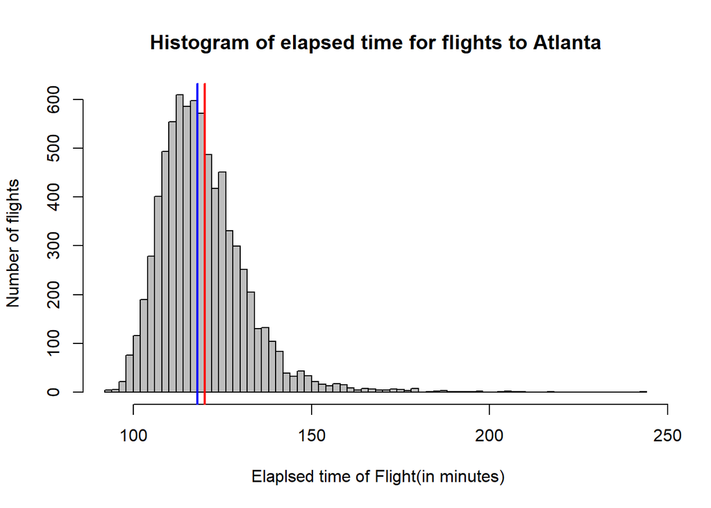

```r
#we are creating histogram with flights going to Atlanta Airport(ATL)
hist(airline$ActualElapsedTime[airline$Dest=="ATL"], breaks=100, col = "grey",
     border = "black", main = "Histogram of elapsed time for flights to Atlanta", xlab=" Elaplsed time of Flight(in minutes)" ,ylab="Number of flights")

#For the mean (red line):
abline(v = mean(airline$ActualElapsedTime[airline$Dest == "ATL"], na.rm = T), col = "red", lwd = 2)
#For the median (blue line):
abline(v = median(airline$ActualElapsedTime[airline$Dest == "ATL"], na.rm = T), col = "blue", lwd = 2)
```